# Data Science Milestone Report

jacethedatascientist

August 18, 2019

# Data Science Capstone

## I. Project Overview

The goal of this project is just to display that you’ve gotten used to working with the data and that you are on track to create your prediction algorithm. You’ll be doing predictive modelling to give the word most likely to follow a word or a group of words.

With this, a large set of text file from twitter, news and blog has been made available in the URL below. During this Capstone Project, we’ll be focusing only on the Txt files in English.

DATA SRC: https://d396qusza40orc.cloudfront.net/dsscapstone/dataset/Coursera-SwiftKey.zip

In this **Milestone Report**, we’ll be discussing the early steps in this project, the initial loading, and exploration, in order to further understand how the data looks like and to decide what further action we’ll be using.

## II. Dataset and Libraries

First is to load the txt files from the internet with link provided **above**. After downloading, read the files.

```r
library(dplyr)
library(stringi)
library(NLP)
library(RWeka)
library(ggplot2)
library(downloader)
```

## III. Exploration

### A. Data Preparation

```r
summary(enBlogs)
```

```
##    Length     Class      Mode
##    899288 character character
```

```r
summary(enNews)
```

```
##    Length     Class      Mode
##     77259 character character
```

```r
summary(enTwitter)
```

```
##    Length     Class      Mode
##   2360148 character character
```

```r
twitterwords <-stri_stats_latex(enTwitter)[4]
blogswords <-stri_stats_latex(enBlogs)[4]
newswords <-stri_stats_latex(enNews)[4]
nchar_twitter<-sum(nchar(enTwitter))
nchar_blogs<-sum(nchar(enBlogs))
nchar_news<-sum(nchar(enNews))

data.frame("File Name" = c("twitter", "blogs", "news"),
           "num.lines" = c(length(enTwitter),length(enBlogs), length(enNews)),
           "num.words" = c(sum(blogswords), sum(newswords), sum(twitterwords)),
           "Num of character"=c(nchar_blogs,nchar_news,nchar_twitter))
```

```
##   File.Name num.lines num.words Num.of.character
## 1   twitter   2360148  37570839        206824505
## 2     blogs    899288   2651432         15639408
## 3      news     77259  30451128        162096031
```

Using only **5%** from each of the Txt files, create a **new sample file** that will, then, be used for the modelling.

```r
set.seed(0000)
enSample <- c(sample(enBlogs, length(enBlogs) * 0.05),
              sample(enNews, length(enNews) * 0.05),
              sample(enTwitter, length(enTwitter) * 0.05)
)
```

### B. Data Pre-processing

1. Convert the TXT files into *Corpus* files.

```r
enCorpus <- VCorpus(VectorSource(enSample))
enCorpus <- tm_map(enCorpus, content_transformer(function(x) iconv(x, to="ASCII", sub = "")))
enCorpus <- tm_map(enCorpus, tolower)
enCorpus <- tm_map(enCorpus, removePunctuation, preserve_intra_word_dashes = TRUE)
enCorpus <- tm_map(enCorpus, removeNumbers)
enCorpus <- tm_map(enCorpus, stripWhitespace)
enCorpus <- tm_map(enCorpus, PlainTextDocument)
```

2. Create a token for each of the corpus files. **NOTE** - *The greater the number of tokens, the more accurate the results, of course, it’d be slower.*

```r
Unigram <- function(x) {NGramTokenizer(x, Weka_control(min = 1,max = 1))}
Bigram <- function(x) {NGramTokenizer(x, Weka_control(min = 2, max = 2))}
Trigram <- function(x) {NGramTokenizer(x, Weka_control(min = 3, max = 3))}
Quadgram <- function(x) {NGramTokenizer(x, Weka_control(min = 4, max = 4))}
Quingram <- function(x) {NGramTokenizer(x, Weka_control(min = 5, max = 5))}
Hexagram <- function(x) {NGramTokenizer(x, Weka_control(min = 6, max = 6))}
Heptagram<- function(x) {NGramTokenizer(x, Weka_control(min = 7, max = 7))}
Octagram <- function(x) {NGramTokenizer(x, Weka_control(min = 8, max = 8))}
Nonagram <- function(x) {NGramTokenizer(x, Weka_control(min = 9, max = 9))}
Decagram <- function(x) {NGramTokenizer(x, Weka_control(min = 10, max = 10))}
```

```r
unigramD <- TermDocumentMatrix(enCorpus, control=list(tokenize=Unigram, wordLengths = c(1, Inf)))
bigramD <- TermDocumentMatrix(enCorpus, control=list(tokenize=Bigram, wordLengths = c(1, Inf)))
trigramD <- TermDocumentMatrix(enCorpus, control=list(tokenize=Trigram, wordLengths = c(1, Inf)))
quadgramD <- TermDocumentMatrix(enCorpus, control=list(tokenize=Quadgram, wordLengths = c(1, Inf)))
quingramD <- TermDocumentMatrix(enCorpus, control=list(tokenize=Quingram, wordLengths = c(1, Inf)))
hexagramD <- TermDocumentMatrix(enCorpus, control=list(tokenize=Hexagram, wordLengths = c(1, Inf)))
heptagramD <- TermDocumentMatrix(enCorpus, control=list(tokenize=Heptagram, wordLengths = c(1, Inf)))
octagramD <- TermDocumentMatrix(enCorpus, control=list(tokenize=Octagram, wordLengths = c(1, Inf)))
nonagramD <- TermDocumentMatrix(enCorpus, control=list(tokenize=Nonagram, wordLengths = c(1, Inf)))
decagramD <- TermDocumentMatrix(enCorpus, control=list(tokenize=Decagram, wordLengths = c(1, Inf)))
```

### C. Plots

For the time being, I’ll be showing you only up to the **Trigram** (*long running time*).

```r
library(tidytext)
unigram_td <- tidy(unigramD)
bigram_td <- tidy(bigramD)
trigram_td <- tidy(trigramD)
quadgram_td <- tidy(quadgramD)
quingram_td <- tidy(quingramD)
hexagram_td <- tidy(hexagramD)
heptagram_td <- tidy(heptagramD)
octagram_td <- tidy(octagramD)
nonagram_td <- tidy(nonagramD)
decagram_td <- tidy(decagramD)
```

```r
unigram_data <- unigram_td[order(-unigram_td$count),]
bigram_data <- bigram_td[order(-bigram_td$count),]
trigram_data <- trigram_td[order(-trigram_td$count),]
quadgram_data <- quadgram_td[order(-quadgram_td$count),]
quingram_data <- quingram_td[order(-quingram_td$count),]
hexagram_data <- hexagram_td[order(-hexagram_td$count),]
heptagram_data <- heptagram_td[order(-heptagram_td$count),]
octagram_data <- octagram_td[order(-octagram_td$count),]
nonagram_data <- nonagram_td[order(-nonagram_td$count),]
decagram_data <- decagram_td[order(-decagram_td$count),]
```

##### UNIGRAM

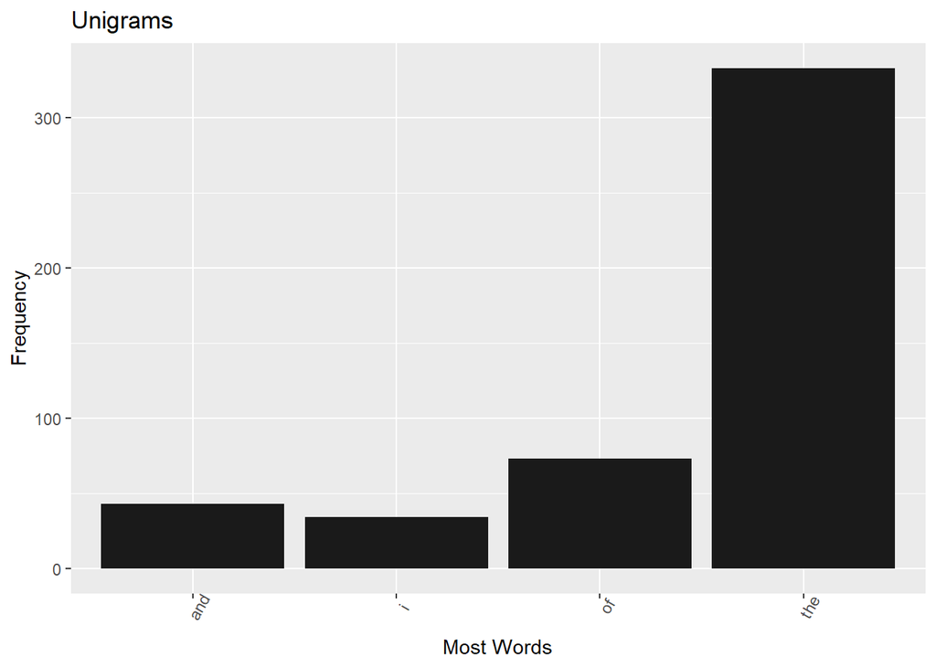

```r
ggplot(head(unigram_data,12), aes(x = term,y = count))+
    geom_bar(stat="identity",fill = I("grey10"))+
    labs(title="Unigrams",x="Most Words",y="Frequency")+
    theme(axis.text.x=element_text(angle=60))
```

##### BIGRAM

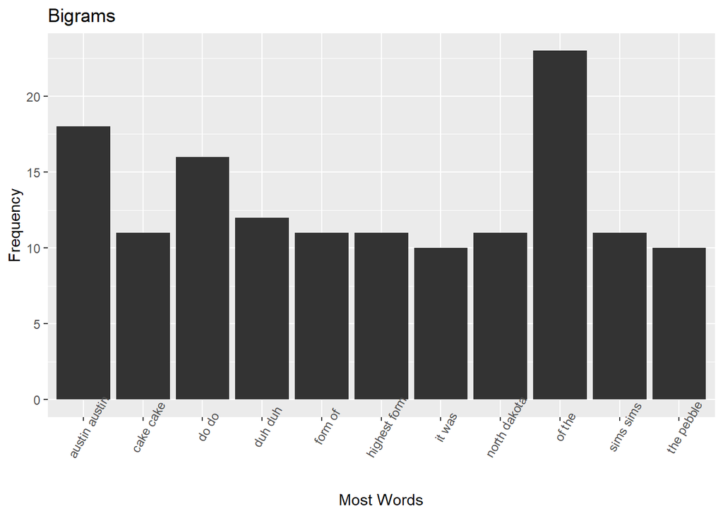

```r
ggplot(head(bigram_data,12), aes(x=term,y=count))+
    geom_bar(stat="identity",fill = I("grey20"))+
    labs(title="Bigrams",x="Most Words",y="Frequency")+
    theme(axis.text.x=element_text(angle=60))
```

##### TRIGRAM

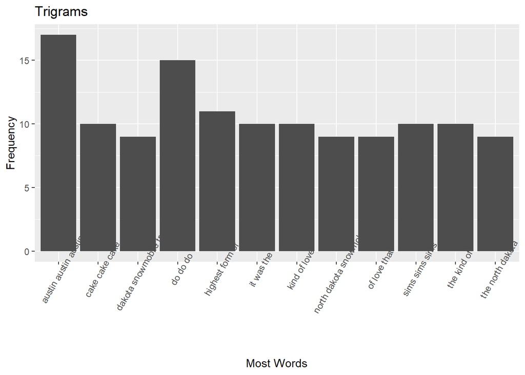

```r
ggplot(head(trigram_data,12), aes(x=term,y=count))+
    geom_bar(stat="identity",fill = I("grey30"))+
    labs(title="Trigrams",x="Most Words",y="Frequency")+
    theme(axis.text.x=element_text(angle=60))
```

## IV. Future Plans

After exploring the txt files by simulating the tokens and creating N-grams from Unigram up to the Trigram, I’ll be: 1. Finalizing the prediction model for each of the N-Gram, up to 10gram; 2. Creating the Shiny App and deploying the model in it; and 3. Creating a Pitch for the app.

*This formally ends the Course Project. Thank You!*